# The impact of gender on earnings project proposal

Group 3: Lorenzo Wahaus, Sonia Duan, Jingrui Zhou

2022-03-02

# Section 1 - Introduction

### Intro

The data that we will be using for our project is the jobs_gender data from the tidytuesday repo. The full url for the data is: “https://raw.githubusercontent.com/rfordatascience/tidytuesday/master/data/2019/2019-03-05/jobs_gender.csv”, and we found the data at: “https://github.com/rfordatascience/tidytuesday/blob/master/data/2019/2019-03-05/jobs_gender.csv”. The data looks at the difference in earnings between men and women across various jobs from 2013-2016. The question we want to answer is what impact gender has on earnings, and if it varies for different jobs or fields.

### Other research

Women have historically been marginalized when it comes to jobs. There is a lot of history of paying women less than men for the same job. With more women joining the workforce than before, gender equality becomes a more and more important issue.

According to the U.S. Bureau of Labor Statistics in 2019, 57.4% of all women were in the labor force, as well as 69.2% of all men. The research also shows that there is a rapid rise of women joining the labor force since the latter half of the 20th century. Following this rise of women working, their earnings as a proportion of men’s earnings rose as well. But, now we want to see how much of a gap there is left to close.

### Details on the data

The data comes from surveys conducted by the Census Bureau and the Bureau of Labor Statistics, which estimately based on the data they collected. The collected data is based on jobs in America and the earnings of the workers in those jobs.

### Code Book

From 2013-2016, the United States Census Bureau and the Bureau of Labor Statistics conducted a monthly survey of households called Current Population Survey. They collected and combined the data together. This data set has been of interest to socialogists who are studying the relation between genders and the paying situation in the job market. The data set contains a random sample of 2088 cases from the data set.

```
##                 variable        NorC
## 1                   year categorical
## 2             occupation categorical
## 3         major_categroy categorical
## 4         minor_category categorical
## 5          total_workers     numeric
## 6           workers_male     numeric
## 7         workers_female     numeric
## 8         percent_female     numeric
## 9         total_earnings     numeric
## 10   total_earnings_male     numeric
## 11 total_earnings_female     numeric
## 12   wage_percent_female     numeric
##                                                  description
## 1                                     year of the data point
## 2                                                        job
## 3                                      broad category of job
## 4                                   specific category of job
## 5                estimated total of full time workers in job
## 6                  estimated total of male full time workers
## 7                estimated total of female full time workers
## 8               percent of estimated workers that are female
## 9         estimated median earnings of all full time workers
## 10   estimated median earnings of all male full time workers
## 11 estimated median earnings of all female full time workers
## 12                    percent of men's wages that women earn
```

### Data Glimpse

```
## Rows: 2,088
## Columns: 12
## $ year                  <dbl> 2013, 2013, 2013, 2013, 2013, 2013, 2013, 2013, …
## $ occupation            <chr> "Chief executives", "General and operations mana…
## $ major_category        <chr> "Management, Business, and Financial", "Manageme…
## $ minor_category        <chr> "Management", "Management", "Management", "Manag…
## $ total_workers         <dbl> 1024259, 977284, 14815, 43015, 754514, 44198, 10…
## $ workers_male          <dbl> 782400, 681627, 8375, 17775, 440078, 16141, 7287…
## $ workers_female        <dbl> 241859, 295657, 6440, 25240, 314436, 28057, 3683…
## $ percent_female        <dbl> 23.6, 30.3, 43.5, 58.7, 41.7, 63.5, 33.6, 27.5, …
## $ total_earnings        <dbl> 120254, 73557, 67155, 61371, 78455, 74114, 62187…
## $ total_earnings_male   <dbl> 126142, 81041, 71530, 75190, 91998, 90071, 66579…
## $ total_earnings_female <dbl> 95921, 60759, 65325, 55860, 65040, 66052, 55079,…
## $ wage_percent_of_male  <dbl> 76.04208, 74.97316, 91.32532, 74.29179, 70.69719…
```

# Section 2 - Data Analysis Plan

### Potential Data Relationships

-Which occupations(occupation) have the biggest gender pay gap(wage_percent_of_male)?

-Does the earnings of women compared to men(wage_percent_of_male) change through the years(year)?

-Does the total amount of workers(total_workers) in a job impact how much women make(total_earnings_female)?

-How does the percent of workers in a job that are women(percent_female) impact femal wages compared to that of men(wage_percent_of_male)?

### Challenges

One potential challenge we could face is that the data only covers 2013 to 2016, no more than four years. This means that we will not be able to look at earnings over a long period of time.

Another challenge is that the data only looks at the job and the earnings. It does not look at other potential impacts on earnings such as education level or jobs available. This means that any earnings differences we find could potentially be a result of unequal access to education or jobs and not necessarily gender.

### Preliminary Exploratory Data Analysis

##### The proportion of female labor force in all job category are shown below.

```
## # A tibble: 8 × 2
##   major_category                                       mean_female_labor
##   <chr>                                                <chr>
## 1 Computer, Engineering, and Science                   27%
## 2 Education, Legal, Community Service, Arts, and Media 54%
## 3 Healthcare Practitioners and Technical               65%
## 4 Management, Business, and Financial                  46%
## 5 Natural Resources, Construction, and Maintenance     6%
## 6 Production, Transportation, and Material Moving      21%
## 7 Sales and Office                                     59%
## 8 Service                                              46%
```

By having such a visualization shown composition of labor force in different *job category*, we are therefore aware that the distribution of labor(with different gender) are not equivalent in different job category and could thus have a **more holistic and un-biased** analysis in our project.

##### Do women make less than men?

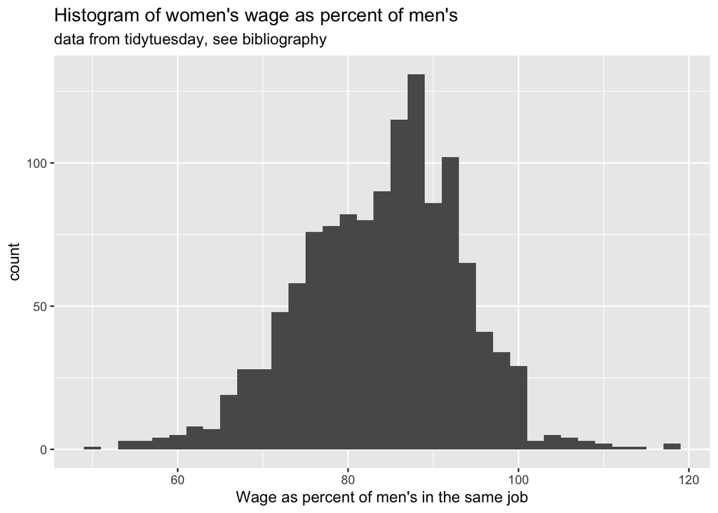

# Section 3 - Bibliography

Jobs gender data: https://raw.githubusercontent.com/rfordatascience/tidytuesday/master/data/2019/2019-03-05/jobs_gender.csv

Women in the labor force: a databook: https://www.bls.gov/opub/reports/womens-databook/2020/home.htm#:~:text=In%202019%2C%2057.4%20percent%20of,of%2060.0%20percent%20in%201999.

…